# Machine Learning Project Trial

## Random Forest

```r
set.seed(7)
rf_full <- randomForest(Satisfaction~., # Set tree formula
                data = train_data, # Set dataset
                mtry = 22, # Set mtry to number of variables
                ntree = 500) # Set number of trees to use
rf_full # View model
```

```
##
## Call:
##  randomForest(formula = Satisfaction ~ ., data = train_data, mtry = 22,      ntree = 500)
##                Type of random forest: classification
##                      Number of trees: 500
## No. of variables tried at each split: 22
##
##         OOB estimate of  error rate: 8.93%
## Confusion matrix:
##              dissatisfied satisfied class.error
## dissatisfied          840        93  0.09967846
## satisfied              94      1068  0.08089501
```

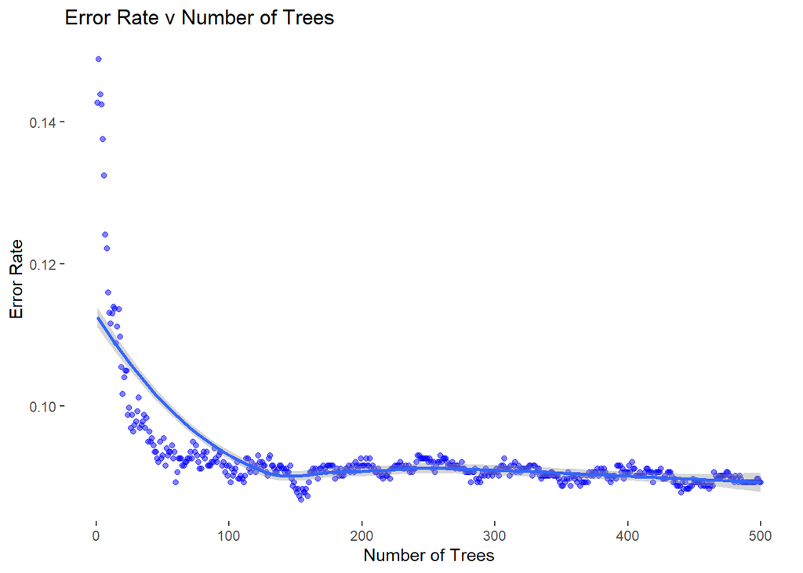

```r
oob_error <- rf_full$err.rate[,1] # Extract oob error
plot_dat <- cbind.data.frame(rep(1:length(oob_error)), oob_error) # Create plot data
names(plot_dat) <- c("trees", "oob_error") # Name plot data

# Plot oob error
g_1 <- ggplot(plot_dat, aes(x = trees, y = oob_error)) + # Set x as trees and y as error
  geom_point(alpha = 0.5, color = "blue") + # Select geom point
  geom_smooth() + # Add smoothing line
  theme_bw() + # Set theme
  theme(panel.grid.major = element_blank(), # Remove grid
        panel.grid.minor = element_blank(), # Remove grid
        panel.border = element_blank(), # Remove grid
        panel.background = element_blank()) + # Remove grid
  labs(x = "Number of Trees", title = "Error Rate v Number of Trees",
       y = "Error Rate")  # Set labels

# Print plot
g_1
```

From the graph above, we can see that the optimal number of iteration is around 100.

```r
# Predict with rf_full
rf_full_pred <- predict(rf_full, test_data, type = "prob")

# Convert predictions to classes, using 0.5
rf_pred_class <- rep("dissatisfied", nrow(rf_full_pred))
rf_pred_class[rf_full_pred[,2] >= 0.5] <- "satisfied"

t <- table(rf_pred_class, test_data$Satisfaction)
rf_full_acc <- confusionMatrix(t, positive = "satisfied")
```

## Parameter tuning

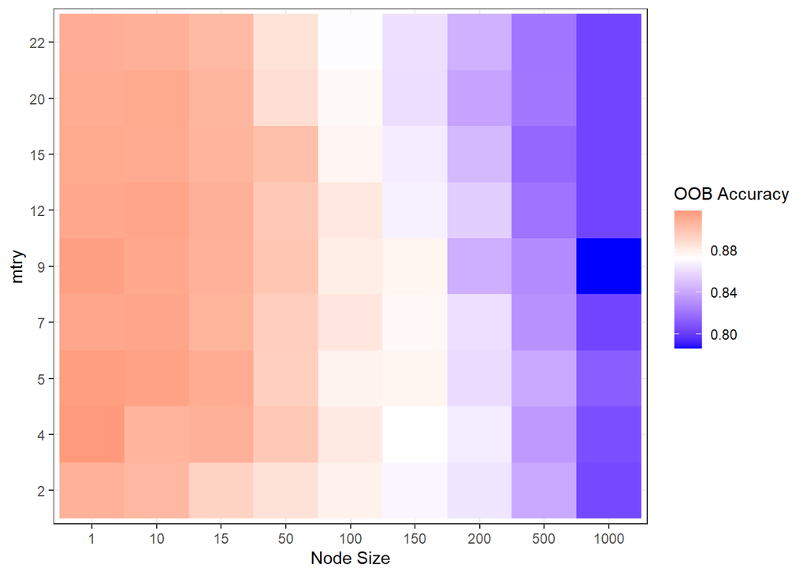

```r
# Set possible values
mtry_vals <- c(2, 4, 5, 7, 9, 12, 15, 20, 22)
nodesize_vals <- c(1, 10, 15, 50, 100, 150, 200, 500, 1000)

params <- expand.grid(mtry_vals, nodesize_vals)
names(params) <- c("mtry", "nodesize")
acc_vec <- rep(NA, nrow(params))
spec_vec <- rep(NA, nrow(params))

# Loop through to find the best combination
for(i in 1:nrow(params)){
  rf_full <- randomForest(factor(Satisfaction) ~., # Set tree formula
                         data = train_data, # Set dataset
                         ntree = 200,
                         nodesize = params$nodesize[i],
                         mtry = params$mtry[i]) # Set number of trees to use
  rf_full_pred <-rf_full$predicted # Create predictions for bagging model

  t <- table(rf_full_pred, train_data$Satisfaction) # Create table
  c <- confusionMatrix(t, positive = "satisfied") # Produce confusion matrix

  acc_vec[i] <- c$overall[1]
  spec_vec[i] <- c$byClass[2]
}

res_db <- cbind.data.frame(params, acc_vec, spec_vec)
res_db$mtry <- as.factor(res_db$mtry) # Convert tree number to factor for plotting
res_db$nodesize <- as.factor(res_db$nodesize) # Convert node size to factor for plotting

# Plot the accuracy heatmap
g_2 <- ggplot(res_db, aes(y = mtry, x = nodesize, fill = acc_vec)) + # set aesthetics
  geom_tile() + # Use geom_tile for heatmap
  theme_bw() + # Set theme
  scale_fill_gradient2(low = "blue", # Choose low color
    mid = "white", # Choose mid color
    high = "red", # Choose high color
    midpoint =mean(res_db$acc_vec), # Choose mid point
    space = "Lab",
    na.value ="grey", # Choose NA value
    guide = "colourbar", # Set color bar
    aesthetics = "fill") + # Select aesthetics to apply
  labs(x = "Node Size", y = "mtry", fill = "OOB Accuracy") # Set labels
g_2 # Generate plot
```

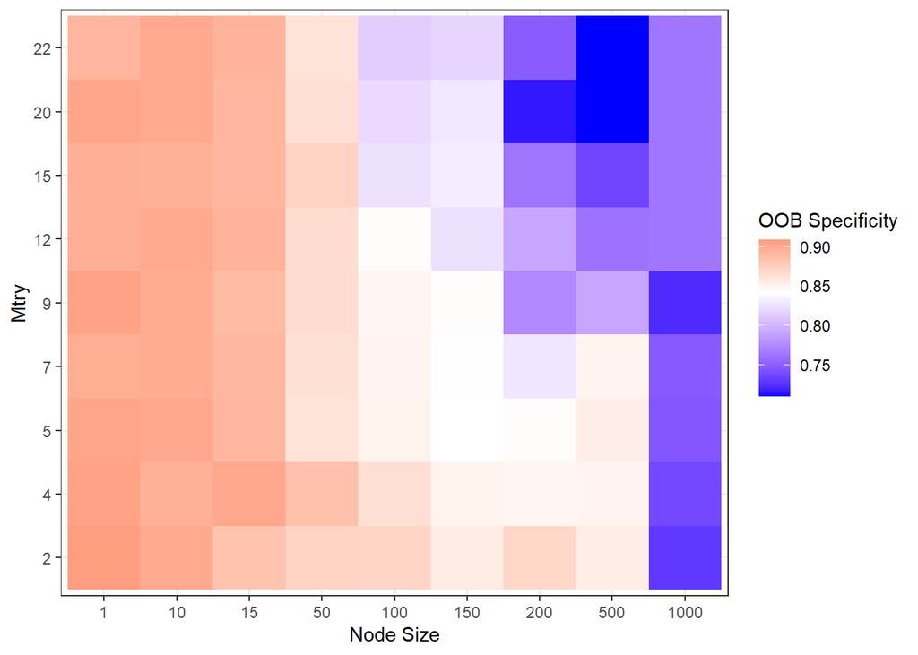

```r
# Plot the specificity heatmap
g_3 <- ggplot(res_db, aes(y = mtry, x = nodesize, fill = spec_vec)) + # set aesthetics
  geom_tile() + # Use geom_tile for heatmap
  theme_bw() + # Set theme
  scale_fill_gradient2(low = "blue", # Choose low color
    mid = "white", # Choose mid color
    high = "red", # Choose high color
    midpoint =mean(res_db$spec_vec), # Choose mid point
    space = "Lab",
    na.value ="grey", # Choose NA value
    guide = "colourbar", # Set color bar
    aesthetics = "fill") + # Select aesthetics to apply
  labs(x = "Node Size", y = "Mtry", fill = "OOB Specificity") # Set labels
g_3 # Generate plot
```

```r
rf_tuned <- randomForest(Satisfaction ~., # Set tree formula
                         data = train_data, # Set dataset
                         ntree = 100,
                         nodesize = 10,
                         mtry = 9) # Set number of trees to use
rf_tuned_pred <- predict(rf_tuned, test_data, type = "prob") # Create predictions for random forest model

# Convert predictions to classes, using 0.5
rf_tuned_pred_class <- rep("dissatisfied", nrow(rf_tuned_pred))
rf_tuned_pred_class[rf_tuned_pred[,2] >= 0.5] <- "satisfied"

t <- table(rf_tuned_pred_class, test_data$Satisfaction) # Create table
rf_tuned_acc <- confusionMatrix(t, positive = "satisfied") # Produce confusion matrix
```

## Bagging

```r
set.seed(111111)
bag_mod <- randomForest(Satisfaction ~.,
                data = train_data,
                mtry = 22,
                ntree = 200)
bag_mod
```

```
##
## Call:
##  randomForest(formula = Satisfaction ~ ., data = train_data, mtry = 22,      ntree = 200)
##                Type of random forest: classification
##                      Number of trees: 200
## No. of variables tried at each split: 22
##
##         OOB estimate of  error rate: 8.64%
## Confusion matrix:
##              dissatisfied satisfied class.error
## dissatisfied          843        90  0.09646302
## satisfied              91      1071  0.07831325
```

```r
bag_pred <- predict(bag_mod, test_data)

t <- table(bag_pred, test_data$Satisfaction)
bag_pred_acc <- confusionMatrix(t, positive = "satisfied")
```

## XGBoost

```r
# Pre-process data
dtrain <- xgb.DMatrix(data = model.matrix(~.,train_data)[, 3:25], label = as.numeric(train_data$Satisfaction) -1)
dtest <- xgb.DMatrix(data = model.matrix(~., test_data)[, 3:25], label = as.numeric(test_data$Satisfaction) - 1)

# Fit a model
set.seed(111111)
bst_1 <- xgboost(data = dtrain,
               nrounds = 200,
               verbose = 1,
               print_every_n = 20,
               objective = "binary:logistic",
               eval_metric = "auc",
               eval_metric = "error")
# decide the number of iteration
set.seed(111111)
bst_1 <- xgb.cv(data = dtrain,
                nfold = 5,
                nrounds = 200,
                verbose = 1,
                print_every_n = 20,
                objective = "binary:logistic",
                eval_metric = "auc",
                eval_metric = "error")
```

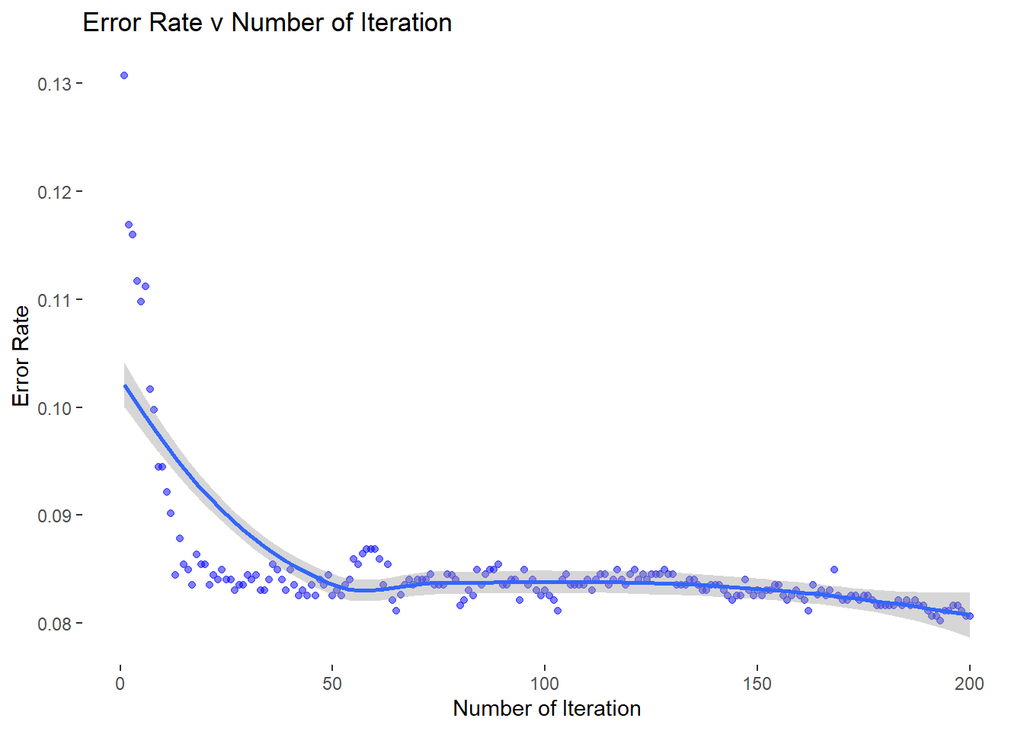

```r
test_error <- bst_1$evaluation_log$test_error_mean
plot_dat <- cbind.data.frame(rep(1:length(test_error)), test_error)
names(plot_dat) <- c("number_of_iteration", "test_error")

# Plot oob error
g_1 <- ggplot(plot_dat, aes(x = number_of_iteration, y = test_error)) +
  geom_point(alpha = 0.5, color = "blue") + # Select geom point
  theme_bw() + # Set theme
  geom_smooth() + # Add smoothing line
  theme(panel.grid.major = element_blank(), # Remove grid
        panel.grid.minor = element_blank(), # Remove grid
        panel.border = element_blank(), # Remove grid
        panel.background = element_blank()) + # Remove grid
  labs(x = "Number of Iteration", title = "Error Rate v Number of Iteration",
       y = "Error Rate")  # Set labels
g_1 # Print plot
```

According to the error rate above, the optimal number of iteration should be 50.

## Find the Best Eta for XGBoost

```r
set.seed(111111)
bst_mod_1 <- xgb.cv(data = dtrain,
              nfold = 5,
              eta = 0.3, # Set learning rate
              max.depth = 7, # Set max depth
              min_child_weight = 10, # Set minimum number of samples in node to split
              gamma = 0, # Set minimum loss reduction for split
              subsample = 0.9, # Set proportion of training data to use in tree
              colsample_bytree =  0.9, # Set number of variables to use in each tree
              nrounds = 150, # Set number of rounds
              early_stopping_rounds = 20, # Set number of rounds to stop at if there is no improvement
              verbose = 1, # 1 - Prints out fit
              nthread = 1, # Set number of parallel threads
              print_every_n = 20, # Prints out result every 20th iteration
              objective = "binary:logistic", # Set objective
              eval_metric = "auc",
              eval_metric = "error") # Set evaluation metric to use
```

```
## Multiple eval metrics are present. Will use test_error for early stopping.
## Will train until test_error hasn't improved in 20 rounds.
##
## Stopping. Best iteration:
```

```r
set.seed(111111)
bst_mod_2 <- xgb.cv(data = dtrain,
              nfold = 5,
              eta = 0.2, # Set learning rate
              max.depth = 7, # Set max depth
              min_child_weight = 10, # Set minimum number of samples in node to split
              gamma = 0, # Set minimum loss reduction for split
              subsample = 0.9, # Set proportion of training data to use in tree
              colsample_bytree =  0.9, # Set number of variables to use in each tree
              nrounds = 150, # Set number of rounds
              early_stopping_rounds = 20, # Set number of rounds to stop at if there is no improvement
              verbose = 1, # 1 - Prints out fit
              nthread = 1, # Set number of parallel threads
              print_every_n = 20, # Prints out result every 20th iteration
              objective = "binary:logistic", # Set objective
              eval_metric = "auc",
              eval_metric = "error") # Set evaluation metric to use
```

```
## Multiple eval metrics are present. Will use test_error for early stopping.
## Will train until test_error hasn't improved in 20 rounds.
##
## Stopping. Best iteration:
```

```r
set.seed(111111)
bst_mod_3 <- xgb.cv(data = dtrain,
              nfold = 5,
              eta = 0.1, # Set learning rate
              max.depth = 7, # Set max depth
              min_child_weight = 10, # Set minimum number of samples in node to split
              gamma = 0, # Set minimum loss reduction for split
              subsample = 0.9, # Set proportion of training data to use in tree
              colsample_bytree =  0.9, # Set number of variables to use in each tree
              nrounds = 150, # Set number of rounds
              early_stopping_rounds = 20, # Set number of rounds to stop at if there is no improvement
              verbose = 1, # 1 - Prints out fit
              nthread = 1, # Set number of parallel threads
              print_every_n = 20, # Prints out result every 20th iteration
              objective = "binary:logistic", # Set objective
              eval_metric = "auc",
              eval_metric = "error") # Set evaluation metric to use
```

```
## Multiple eval metrics are present. Will use test_error for early stopping.
## Will train until test_error hasn't improved in 20 rounds.
##
## Stopping. Best iteration:
```

```r
set.seed(111111)
bst_mod_4 <- xgb.cv(data = dtrain,
              nfold = 5,
              eta = 0.05, # Set learning rate
              max.depth = 7, # Set max depth
              min_child_weight = 10, # Set minimum number of samples in node to split
              gamma = 0, # Set minimum loss reduction for split
              subsample = 0.9, # Set proportion of training data to use in tree
              colsample_bytree =  0.9, # Set number of variables to use in each tree
              nrounds = 150, # Set number of rounds
              early_stopping_rounds = 20, # Set number of rounds to stop at if there is no improvement
              verbose = 1, # 1 - Prints out fit
              nthread = 1, # Set number of parallel threads
              print_every_n = 20, # Prints out result every 20th iteration
              objective = "binary:logistic", # Set objective
              eval_metric = "auc",
              eval_metric = "error") # Set evaluation metric to use
```

```
## Multiple eval metrics are present. Will use test_error for early stopping.
## Will train until test_error hasn't improved in 20 rounds.
##
```

```r
set.seed(111111)
bst_mod_5 <- xgb.cv(data = dtrain,
              nfold = 5,
              eta = 0.01, # Set learning rate
              max.depth = 7, # Set max depth
              min_child_weight = 10, # Set minimum number of samples in node to split
              gamma = 0, # Set minimum loss reduction for split
              subsample = 0.9, # Set proportion of training data to use in tree
              colsample_bytree =  0.9, # Set number of variables to use in each tree
              nrounds = 150, # Set number of rounds
              early_stopping_rounds = 20, # Set number of rounds to stop at if there is no improvement
              verbose = 1, # 1 - Prints out fit
              nthread = 1, # Set number of parallel threads
              print_every_n = 20, # Prints out result every 20th iteration
              objective = "binary:logistic", # Set objective
              eval_metric = "auc",
              eval_metric = "error") # Set evaluation metric to use
```

```
## Multiple eval metrics are present. Will use test_error for early stopping.
## Will train until test_error hasn't improved in 20 rounds.
##
## Stopping. Best iteration:
```

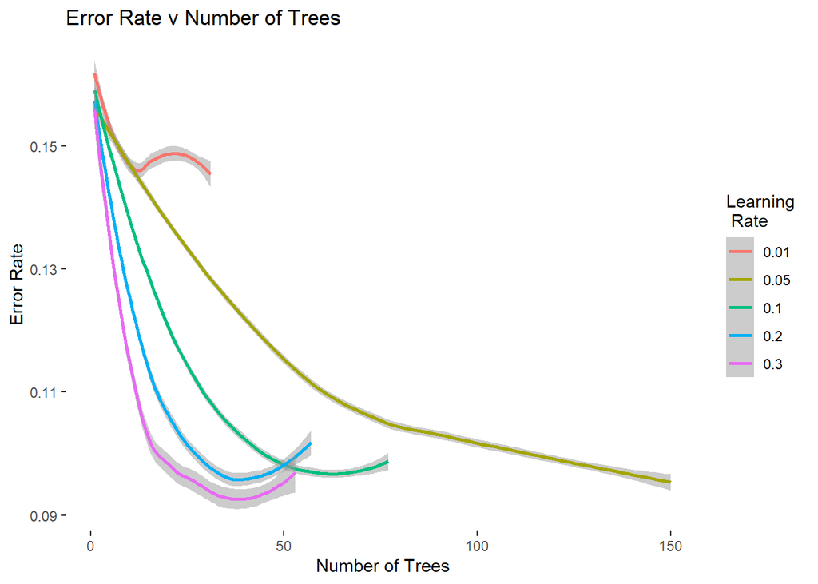

```r
# Extract results for model with eta = 0.3
pd1 <- cbind.data.frame(bst_mod_1$evaluation_log[,c("iter", "test_error_mean")], rep(0.3, nrow(bst_mod_1$evaluation_log)))
names(pd1)[3] <- "eta"
# Extract results for model with eta = 0.2
pd2 <- cbind.data.frame(bst_mod_2$evaluation_log[,c("iter", "test_error_mean")], rep(0.2, nrow(bst_mod_2$evaluation_log)))
names(pd2)[3] <- "eta"
# Extract results for model with eta = 0.1
pd3 <- cbind.data.frame(bst_mod_3$evaluation_log[,c("iter", "test_error_mean")], rep(0.1, nrow(bst_mod_3$evaluation_log)))
names(pd3)[3] <- "eta"
# Extract results for model with eta = 0.05
pd4 <- cbind.data.frame(bst_mod_4$evaluation_log[,c("iter", "test_error_mean")], rep(0.05, nrow(bst_mod_4$evaluation_log)))
names(pd4)[3] <- "eta"
# Extract results for model with eta = 0.01
pd5 <- cbind.data.frame(bst_mod_5$evaluation_log[,c("iter", "test_error_mean")], rep(0.01, nrow(bst_mod_5$evaluation_log)))
names(pd5)[3] <- "eta"
# Join datasets
plot_data <- rbind.data.frame(pd1, pd2, pd3, pd4, pd5)
# Convert ETA to factor
plot_data$eta <- as.factor(plot_data$eta)
# Plot lines
g_2 <- ggplot(plot_data, aes(x = iter, y = test_error_mean, color = eta))+
  geom_smooth(alpha = 0.5) +
  theme_bw() + # Set theme
  theme(panel.grid.major = element_blank(), # Remove grid
        panel.grid.minor = element_blank(), # Remove grid
        panel.border = element_blank(), # Remove grid
        panel.background = element_blank()) + # Remove grid
  labs(x = "Number of Trees", title = "Error Rate v Number of Trees",
       y = "Error Rate", color = "Learning \n Rate")  # Set labels
g_2
```

## Find the Most Important Features via XGBoost

```r
set.seed(111111)
bst_final <- xgboost(data = dtrain, # Set training data
              eta = 0.05, # Set learning rate
              max.depth =  7, # Set max depth
              min_child_weight = 10, # Set minimum number of samples in node to split
              gamma = 0, # Set minimum loss reduction for split
              subsample =  0.9, # Set proportion of training data to use in tree
              colsample_bytree = 0.9, # Set number of variables to use in each tree
              nrounds = 50, # Set number of rounds
              early_stopping_rounds = 20, # Set number of rounds to stop at if there is no improvement
              verbose = 1, # 1 - Prints out fit
              nthread = 1, # Set number of parallel threads
              print_every_n = 20, # Prints out result every 20th iteration
              objective = "binary:logistic", # Set objective
              eval_metric = "auc",
              eval_metric = "error") # Set evaluation metric to use
```

```
## Multiple eval metrics are present. Will use train_error for early stopping.
## Will train until train_error hasn't improved in 20 rounds.
##
```

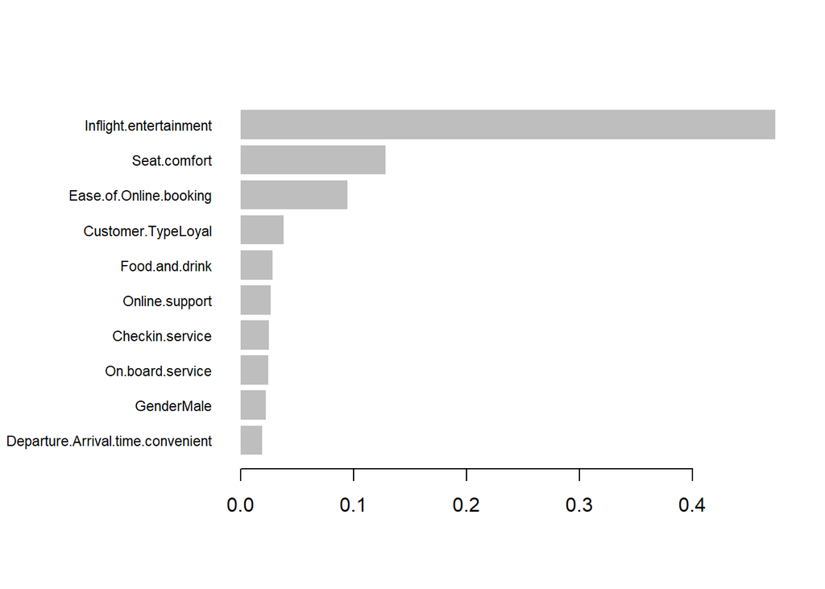

```r
# Extract importance
imp_mat <- xgb.importance(model = bst_final)
# Plot importance (top 10 variables)
xgb.plot.importance(imp_mat, top_n = 10)
```

According to the variable importance graph, `Inflight.entertainment`, `Seat.Comfort`, and `Ease.of.Online.Booking` are the most important variables to affect overall satisfaction.

## Examine the Most Important Variables for Each Cluster

```r
x_vars <- model.matrix(~.,train_data)[, 3:25]

shap_values <- predict(bst_final,
                     model.matrix(~.,train_data)[, 3:25],
                    predcontrib = TRUE,
                    approxcontrib = F)

train_clusters <- clusters[train_data_indices]

c1_shap <- colMeans(shap_values[which(train_clusters == 1),])
c1_shap[order(abs(c1_shap), decreasing = TRUE)[1:4]]
```

```
##                   BIAS           Seat.comfort     Customer.TypeLoyal
##             0.24637857             0.12392628             0.09105852
## Type.of.TravelPersonal
##            -0.08625187
```

```r
# Inflight.entertainment, Ease.of.Online.booking, Seat.comfort

c2_shap <- colMeans(shap_values[which(train_clusters == 2),])
c2_shap[order(abs(c2_shap), decreasing = TRUE)[1:6]] # use 1:6 to make sure enough scored factors appear in the result
```

```
## Inflight.entertainment     Customer.TypeLoyal                   BIAS
##            -0.49159427            -0.43213323             0.24637857
## Ease.of.Online.booking Type.of.TravelPersonal           Seat.comfort
##            -0.12706508             0.07301699            -0.06302180
```

```r
# Inflight.entertainment, Ease.of.Online.booking, Seat.comfort

c3_shap <- colMeans(shap_values[which(train_clusters == 3),])
c3_shap[order(abs(c3_shap), decreasing = TRUE)[1:8]]
```

```
## Inflight.entertainment                   BIAS Type.of.TravelPersonal
##             0.32802557             0.24637857             0.09497079
##           Seat.comfort     Customer.TypeLoyal               ClassEco
##             0.08552245             0.06629779             0.05273116
## Ease.of.Online.booking        Online.boarding
##             0.04196124             0.01993721
```

```r
# Inflight.entertainment, seat.comfort, Ease.of.Online.booking

c4_shap <- colMeans(shap_values[which(train_clusters == 4),])
c4_shap[order(abs(c4_shap), decreasing = TRUE)[1:7]]
```

```
## Inflight.entertainment                   BIAS Type.of.TravelPersonal
##            -0.29220272             0.24637857            -0.15476217
##     Customer.TypeLoyal Ease.of.Online.booking             GenderMale
##             0.10213312            -0.07866327            -0.07032762
##           Seat.comfort
##             0.05037171
```

```r
# Inflight.entertainment, Ease.of.Online.booking, Seat.comfort

c5_shap <- colMeans(shap_values[which(train_clusters == 5),])
c5_shap[order(abs(c5_shap), decreasing = TRUE)[1:5]]
```

```
## Inflight.entertainment                   BIAS Type.of.TravelPersonal
##             0.35917775             0.24637857             0.10795406
##           Seat.comfort Ease.of.Online.booking
##             0.10735669             0.08364725
```

```r
# Seat.comfort, GenderMale, Ease.of.Online.booking, Online.boarding
```

## Compare Models with ROC

```r
# Generate predictions
lm_full_pred <- predict(lm_full, test_data, type = 'response')
lm_bwd_pred <- predict(lm_bwd, test_data, type = 'response')
gam_full_pred <- predict(gam_full, test_data, type = 'response')
nn_full_pred <- predict(nn_full, newdata=x_test_nn)[,1]
tree_full_pred <- predict(tree_full, test_data)
tree_trimed_pred <- predict(tree_trimed, test_data)
rf_full_pred <- predict(rf_full, test_data, type = "prob")
rf_tuned_pred <- predict(rf_tuned, test_data, type = "prob")
bag_pred <- predict(bag_mod, test_data, type = 'prob')
bst_final_pred <- predict(bst_final, dtest)

# Calculate ROC
roc_lm_full = roc(test_data$Satisfaction, lm_full_pred)
roc_lm_bwd = roc(test_data$Satisfaction, lm_bwd_pred)
roc_gam = roc(test_data$Satisfaction, gam_full_pred)
roc_nn = roc(test_data$Satisfaction, nn_full_pred)
roc_tree_full = roc(test_data$Satisfaction, tree_full_pred[,2])
roc_tree_trimed = roc(test_data$Satisfaction, tree_trimed_pred[,2])
roc_rf_full = roc(test_data$Satisfaction, rf_full_pred[,2])
roc_rf_tuned = roc(test_data$Satisfaction, rf_tuned_pred[,2])
roc_bag = roc(test_data$Satisfaction, bag_pred[,2])
roc_bst = roc(test_data$Satisfaction, bst_final_pred)
```

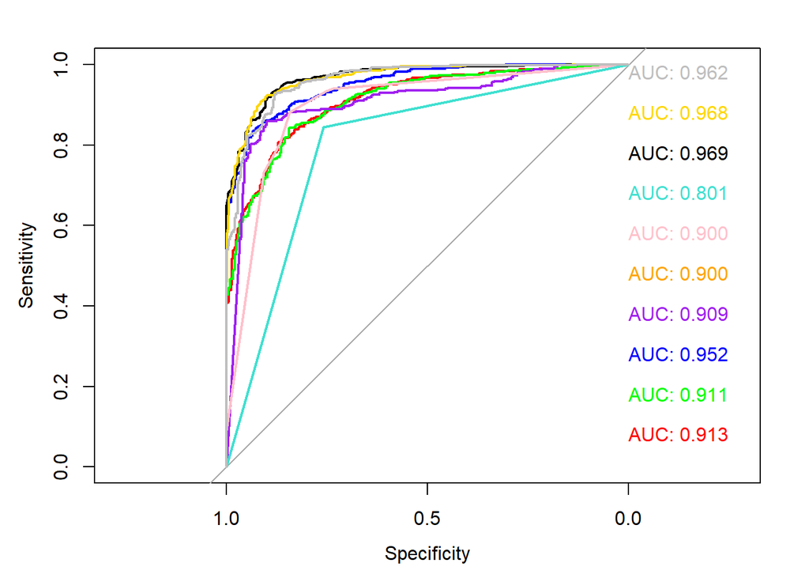

```r
# plot
plot.roc(roc_lm_full, print.auc = TRUE, print.auc.x = 0, print.auc.y = 0.1, col = "red", print.auc.col = "red")
plot.roc(roc_lm_bwd, print.auc = TRUE, print.auc.x = 0, print.auc.y = 0.2, col ="green", print.auc.col = "green", add = TRUE)
plot.roc(roc_gam, print.auc = TRUE, print.auc.x = 0, print.auc.y = 0.3, col ="blue", print.auc.col = "blue", add = TRUE)
plot.roc(roc_nn, print.auc = TRUE, print.auc.x = 0, print.auc.y = 0.4, col ="purple", print.auc.col = "purple", add = TRUE)
plot.roc(roc_tree_full, print.auc = TRUE, print.auc.x = 0, print.auc.y = 0.5, col ="orange", print.auc.col = "orange", add = TRUE)
plot.roc(roc_tree_trimed, print.auc = TRUE, print.auc.x = 0, print.auc.y = 0.6, col ="pink", print.auc.col = "pink", add = TRUE)
plot.roc(roc_rf_full, print.auc = TRUE, print.auc.x = 0, print.auc.y = 0.7, col ="turquoise", print.auc.col = "turquoise", add = TRUE)
plot.roc(roc_rf_tuned, print.auc = TRUE, print.auc.x = 0, print.auc.y = 0.8, col ="black", print.auc.col = "black", add = TRUE)
plot.roc(roc_bag, print.auc = TRUE, print.auc.x = 0, print.auc.y = 0.9, col ="gold", print.auc.col = "gold", add = TRUE)
plot.roc(roc_bst, print.auc = TRUE, print.auc.x = 0, print.auc.y = 1, col ="gray", print.auc.col = "gray", add = TRUE)
```

According to the AUC chart above, rf_tuned gives the best predictions as they have the highest accuracy rate, and thus we should choose rf_tuned to predict satisfaction.